# Analyze and plot the GAM results for significant fixel cluster

Chenying Zhao

This script is to analyze the fixel cluster of significance.  
Here, python file = ModelArray_paper/notebooks/analyze_signi_cluster.py  
Steps:  
0. Preparation  
- Convert results from .h5 to .mif  
- View in mrview, set a threshold, then draw an ROI as mask, save it  
- example filename: ROI_x69_sage_p_lt_1e-15.mif

1. [python] function: convert_voxelMask_to_fixelIndex()
   - This will generate the list of fixel’s ids that included in manually drawn mask (ROI.mif). This also includes those fixels that do not meet thresholding criteria (although the filename might be misleading to contain e.g. “lt_1e-15”)
   - example filename: ROI_x69_sage_p_lt_1e-15_fixelIdList.txt
2. [R] All significant fixels: the list
   - load in the .h5 file (with output such as p.value after bonferroni correction)
   - threshold, get the list of all significant fixels
   - example filename: gam_allOutputs_s_Age.p.value_lt_1e-15_fixelIdList.txt
3. [R] take the intersect of 1 and 2; save it.
   - example filename: gam_allOutputs_s_Age.p.value_lt_1e-15__Intersect__ROI_x69_sage_p_lt_1e-15_fixelIdList.txt
4. [python] function: save_selectedFixel_mask()
   - This is to verify that the intersect list we saved is visually correct.
   - The function will save a ‘mask’ of intersected fixels we just saved.
   - You should visually verify it in mrview. See instructions at the end of the function.
   - example filename: gam_allOutputs_s_Age.p.value_lt_1e-15__Intersect__ROI_x69_sage_p_lt_1e-15_fixelIdList.mif
5. [R] Analyze the intersect
   - make sure that all fixels selected meet the thresholding criteria (expect_true())
   - average the values across all fixels in this cluster, re-fit GAM, print out statistics, and generate the figure.

## Set up

```r
# install ModelArray package:

#ModelArray_commitSHA = "9e735b93f2d6b756f8ef18aadc14e2d10c6cc191" # +++++++++++++++
ModelArray_commitSHA = "0911c4ffbcc737ea9a615f7a663f57bb0b4e174d"   # ++++++++++++++++=

devtools::install_github(paste0("PennLINC/ModelArray@", ModelArray_commitSHA),   # install_github("username/repository@commitSHA")
                         upgrade = "never",  # not to upgrade package dependencies
                         force=FALSE)   # force re-install ModelArray again or not
```

```
## Skipping install of 'ModelArray' from a github remote, the SHA1 (0911c4ff) has not changed since last install.
##   Use `force = TRUE` to force installation
```

```r
library(ModelArray)

source("GAMM_plotting.R")   # Bart Larsen's function for visualizing gam results
source("utils.R")   # source partialRsq()
```

## Input arguments, PLEASE REVIEW AND CHANGE AS NEEDED!

```r
num.subj <- 938
fn.h5.results <- paste0("../../data/data_from_josiane/results/ltn_FDC_n",toString(num.subj),"_wResults_nfixels-0_20220109-183909.h5")
fn_csv <- paste0("../../data/data_from_josiane/df_example_n", toString(num.subj), ".csv")
scalar_name <- c("FDC")

analysis_name <- "gam_allOutputs"

# stat_name_thr <- "s_Age.p.value.bonferroni"   # the stat name for thresholding
# flag_compare <- "lt"
# thr <- 1e-20

stat_name_thr <- "s_Age.p.value"  # the stat name for thresholding
flag_compare <- "lt"
thr <- 1e-15

# stat_name_thr <- "s_Age.eff.size"
# flag_compare <- "gt"
# thr <- 0.2

## step 2:
flag_run_step2 <- FALSE   # run once is enough; independent from python's output

flag_flipFixel_roi <- TRUE
flag_flipFixel_signi <- FALSE

## step 3:
flag_run_step3 <- FALSE
# filename.fixelIdListMask <- "ROI_x65_sage_p_bonfer_lt_1e-20_fixelIdList.txt"  # for step 3
filename.fixelIdListMask <- "ROI_x69_sage_p_lt_1e-15_fixelIdList.txt"  # for step 3

## step 5:
stat_toPlot <- "s_Age.eff.size"
formula <- FDC ~ s(Age, k=4, fx=TRUE) + sex + dti64MeanRelRMS
method.gam.refit <- "REML"   # +++++++++++++++
main.folder.figures <- "/home/chenying/Desktop/fixel_project/ModelArray_paper/figures"
```

## Step 2: Thresholding

## Step 3: Getting the intersection

## Step 4: Please verify selected fixel ids! See python file.

## Step 5: Average and plot

```
## the final list of fixel ids selected is in file:
```

```
## ../../data/data_from_josiane/results/ltn_FDC_n938_wResults_nfixels-0_20220109-183909/gam_allOutputs_s_Age.p.value_lt_1e-15__Intersect__ROI_x69_sage_p_lt_1e-15_fixelIdList.txt
```

```
## number of fixels selected (i.e. within the ROI & meeting the threshold criteria:
```

```
## [1] 185
```

```
## For the fixels in this cluster (i.e. fixels meeting thresholding criteria):
```

```
## max raw p.value:
```

```
## [1] 7.152777e-16
```

```
## max p.value after bonferroni:
```

```
## [1] 4.30761e-10
```

```
## number of fixels:
```

```
## [1] 602229
```

```
## summary for GAM for averaged values of this cluster:
```

```
##
## Family: gaussian
## Link function: identity
##
## Formula:
## FDC ~ s(Age, k = 4, fx = TRUE) + sex + dti64MeanRelRMS
##
## Parametric coefficients:
##                  Estimate Std. Error t value Pr(>|t|)
## (Intercept)      0.981514   0.015148  64.796  < 2e-16 ***
## sex             -0.030164   0.008751  -3.447 0.000592 ***
## dti64MeanRelRMS  0.005006   0.012710   0.394 0.693800
## ---
## Signif. codes:  0 '***' 0.001 '**' 0.01 '*' 0.05 '.' 0.1 ' ' 1
##
## Approximate significance of smooth terms:
##        edf Ref.df     F p-value
## s(Age)   3      3 82.38  <2e-16 ***
## ---
## Signif. codes:  0 '***' 0.001 '**' 0.01 '*' 0.05 '.' 0.1 ' ' 1
##
## R-sq.(adj) =  0.217   Deviance explained = 22.2%
## -REML = -543.32  Scale est. = 0.017643  n = 938
```

```
## [1] "s(Age)'s p.value of re-fit after avg in this cluster = 2.80358872887457e-47"
```

```
## [1] "s(Age)'s effect size of re-fit after avg in this cluster = 0.204"
```

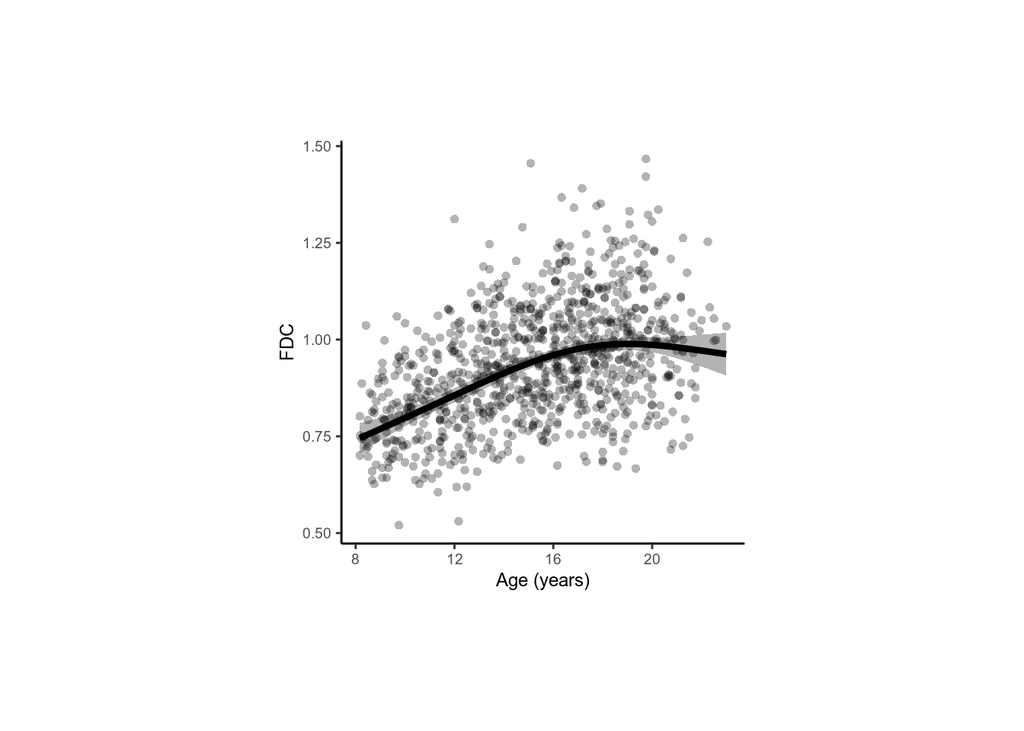

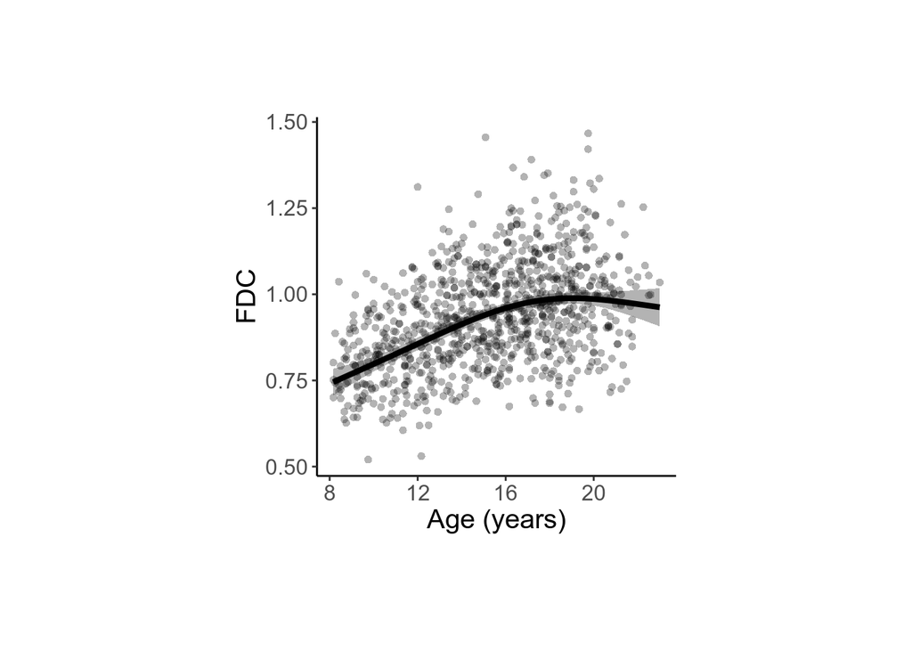